# Hope your will Enjoy my notebook, let's start coding ^^

The problem is about cleaning the solarPrediction dataset, I will start by loading my dataset from my drive because I am using Google Colab

# Loading My Drive

```python
from google.colab import drive
drive.mount('/content/drive/')
```

After loading my drive, now I only need to give the path to my dataset to load it.

# Import the necessary packages

```python
import pandas as pd
import numpy as np
import matplotlib.pyplot as plt
from sklearn.model_selection import train_test_split
from sklearn.tree import DecisionTreeClassifier
from sklearn.metrics import accuracy_score
import seaborn as sns
from sklearn.preprocessing import LabelEncoder, StandardScaler
from sklearn.decomposition import PCA
```

# Load the dataset

My dataset is located in the folder Colab Notebooks that is in my drive

```python
file_path = '/content/drive/My Drive/Colab Notebooks/SolarPrediction.csv'
dataset = pd.read_csv(file_path, parse_dates=['Data'])
```

# Identification of variables and data types

First, let check if the data is loaded correctly and visualize the five first records.

```python
dataset.head()
```

|  | UNIXTime | Data | Time | Radiation | Temperature | Pressure | Humidity | WindDirection(Degrees) | Speed | TimeSunRise | TimeSunSet |
| --- | --- | --- | --- | --- | --- | --- | --- | --- | --- | --- | --- |
| 0 | 1475229326 | 2016-09-29 | 23:55:26 | 1.21 | 48 | 30.46 | 59 | 177.39 | 5.62 | 06:13:00 | 18:13:00 |
| 1 | 1475229023 | 2016-09-29 | 23:50:23 | 1.21 | 48 | 30.46 | 58 | 176.78 | 3.37 | 06:13:00 | 18:13:00 |
| 2 | 1475228726 | 2016-09-29 | 23:45:26 | 1.23 | 48 | 30.46 | 57 | 158.75 | 3.37 | 06:13:00 | 18:13:00 |
| 3 | 1475228421 | 2016-09-29 | 23:40:21 | 1.21 | 48 | 30.46 | 60 | 137.71 | 3.37 | 06:13:00 | 18:13:00 |
| 4 | 1475228124 | 2016-09-29 | 23:35:24 | 1.17 | 48 | 30.46 | 62 | 104.95 | 5.62 | 06:13:00 | 18:13:00 |

Now, let's take a look at the shape of the dataset, How many raws? and How many columns?

```python
dataset.shape
```

```
(32686, 11)
```

Here we go, we have 32686 raws and 11 columns

Now, let's display the name of all te columns

```python
dataset.columns
```

```
Index(['UNIXTime', 'Data', 'Time', 'Radiation', 'Temperature', 'Pressure',
       'Humidity', 'WindDirection(Degrees)', 'Speed', 'TimeSunRise',
       'TimeSunSet'],
      dtype='object')
```

are you wondering the values of each column?

```python
dataset.values
```

```
array([[1475229326, Timestamp('2016-09-29 00:00:00'), '23:55:26', ...,
        5.62, '06:13:00', '18:13:00'],
       [1475229023, Timestamp('2016-09-29 00:00:00'), '23:50:23', ...,
        3.37, '06:13:00', '18:13:00'],
       [1475228726, Timestamp('2016-09-29 00:00:00'), '23:45:26', ...,
        3.37, '06:13:00', '18:13:00'],
       ...,
       [1480587001, Timestamp('2016-12-01 00:00:00'), '00:10:01', ...,
        9.0, '06:41:00', '17:42:00'],
       [1480586702, Timestamp('2016-12-01 00:00:00'), '00:05:02', ...,
        7.87, '06:41:00', '17:42:00'],
       [1480586402, Timestamp('2016-12-01 00:00:00'), '00:00:02', ...,
        3.37, '06:41:00', '17:42:00']], dtype=object)
```

Finally, we check for the type of each column

```python
dataset.dtypes
```

```
UNIXTime                           int64
Data                      datetime64[ns]
Time                              object
Radiation                        float64
Temperature                        int64
Pressure                         float64
Humidity                           int64
WindDirection(Degrees)           float64
Speed                            float64
TimeSunRise                       object
TimeSunSet                        object
dtype: object
```

we are done for this part, let's move on ^^

# Analyze Basic metrics

The following table summarize some values of the dataframe

```python
dataset.describe()
```

|  | UNIXTime | Radiation | Temperature | Pressure | Humidity | WindDirection(Degrees) | Speed |
| --- | --- | --- | --- | --- | --- | --- | --- |
| count | 3.268600e+04 | 32686.000000 | 32686.000000 | 32686.000000 | 32686.000000 | 32686.000000 | 32686.000000 |
| mean | 1.478047e+09 | 207.124697 | 51.103255 | 30.422879 | 75.016307 | 143.489821 | 6.243869 |
| std | 3.005037e+06 | 315.916387 | 6.201157 | 0.054673 | 25.990219 | 83.167500 | 3.490474 |
| min | 1.472724e+09 | 1.110000 | 34.000000 | 30.190000 | 8.000000 | 0.090000 | 0.000000 |
| 25% | 1.475546e+09 | 1.230000 | 46.000000 | 30.400000 | 56.000000 | 82.227500 | 3.370000 |
| 50% | 1.478026e+09 | 2.660000 | 50.000000 | 30.430000 | 85.000000 | 147.700000 | 5.620000 |
| 75% | 1.480480e+09 | 354.235000 | 55.000000 | 30.460000 | 97.000000 | 179.310000 | 7.870000 |
| max | 1.483265e+09 | 1601.260000 | 71.000000 | 30.560000 | 103.000000 | 359.950000 | 40.500000 |

We can get the min, max, and mean of each column. how many record in each column and may others.

let's get the unique values of the target

```python
dataset['Radiation'].unique()
```

```
array([1.21, 1.23, 1.17, ..., 7.04, 4.45, 4.29])
```

What is the mean value of the radiation

```python
dataset['Radiation'].mean()
```

```
207.12469742399261
```

let display all the records that are > than the mean

```python
dataset[(dataset['Radiation'] > dataset['Radiation'].mean())]
```

|  | UNIXTime | Data | Time | Radiation | Temperature | Pressure | Humidity | WindDirection(Degrees) | Speed | TimeSunRise | TimeSunSet |
| --- | --- | --- | --- | --- | --- | --- | --- | --- | --- | --- | --- |
| 82 | 1475204722 | 2016-09-29 | 17:05:22 | 240.99 | 58 | 30.43 | 45 | 132.36 | 5.62 | 06:13:00 | 18:13:00 |
| 83 | 1475204424 | 2016-09-29 | 17:00:24 | 274.83 | 58 | 30.43 | 41 | 332.09 | 4.50 | 06:13:00 | 18:13:00 |
| 84 | 1475204125 | 2016-09-29 | 16:55:25 | 300.94 | 58 | 30.43 | 55 | 45.88 | 3.37 | 06:13:00 | 18:13:00 |
| 85 | 1475203822 | 2016-09-29 | 16:50:22 | 322.71 | 58 | 30.43 | 56 | 94.24 | 7.87 | 06:13:00 | 18:13:00 |
| 86 | 1475203538 | 2016-09-29 | 16:45:38 | 346.59 | 58 | 30.43 | 50 | 81.57 | 6.75 | 06:13:00 | 18:13:00 |
| ... | ... | ... | ... | ... | ... | ... | ... | ... | ... | ... | ... |
| 32562 | 1480623305 | 2016-12-01 | 10:15:05 | 721.71 | 47 | 30.42 | 99 | 147.67 | 9.00 | 06:41:00 | 17:42:00 |
| 32563 | 1480623004 | 2016-12-01 | 10:10:04 | 588.80 | 47 | 30.42 | 100 | 190.74 | 9.00 | 06:41:00 | 17:42:00 |
| 32564 | 1480622701 | 2016-12-01 | 10:05:01 | 527.28 | 46 | 30.42 | 100 | 141.80 | 9.00 | 06:41:00 | 17:42:00 |
| 32565 | 1480622402 | 2016-12-01 | 10:00:02 | 319.44 | 45 | 30.42 | 99 | 30.08 | 3.37 | 06:41:00 | 17:42:00 |
| 32582 | 1480617302 | 2016-12-01 | 08:35:02 | 237.99 | 44 | 30.41 | 100 | 162.61 | 12.37 | 06:41:00 | 17:42:00 |

10222 rows × 11 columns

there are in total 10222 record

Let's display how many null value in the dataset

```python
dataset.isnull().sum()
```

```
UNIXTime                  0
Data                      0
Time                      0
Radiation                 0
Temperature               0
Pressure                  0
Humidity                  0
WindDirection(Degrees)    0
Speed                     0
TimeSunRise               0
TimeSunSet                0
dtype: int64
```

Sounds to be great, no null value in the dataset

# Graphical Univariate Analysis

As they say, a chart can say better words then text, so let's visualize our dataset

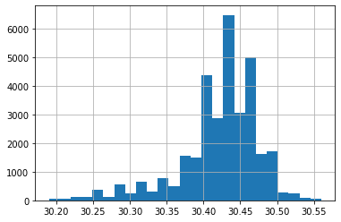

```python
dataset['Pressure'].hist(bins=25)
```

There are some outliers in left and right

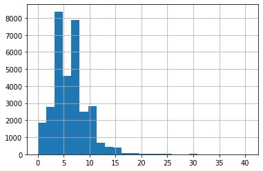

```python
dataset['Speed'].hist(bins=25)
```

Some outliers in the right

TO better detect the outliers, it is better to use BoxPlot, I will use it for the same previous one

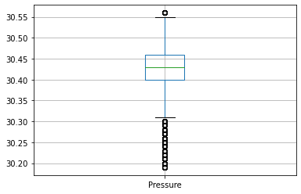

```python
dataset.boxplot(column='Pressure')
```

You can see the outlier is in the left and right as described previously. Let's check for the speed before to move on

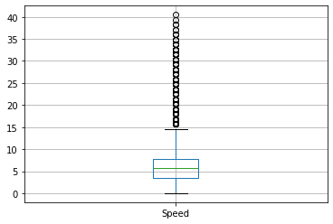

```python
dataset.boxplot(column='Speed')
```

and Boom, ok let's move on

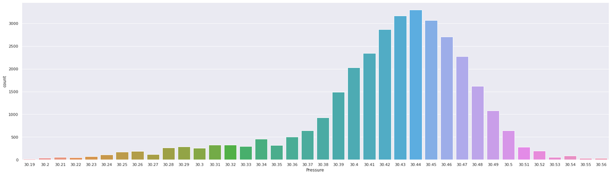

```python
sns.set(rc={'figure.figsize':(30.0,8.27)})
sns.countplot(dataset.Pressure)
```

The range 30.42 to 30.45 is dominating the dataset

Obviously, we can enjoy doing this for all the columns and extract some useful analysts

# Bivariate Analysis

Let's start with the simplest one

[output not shown]

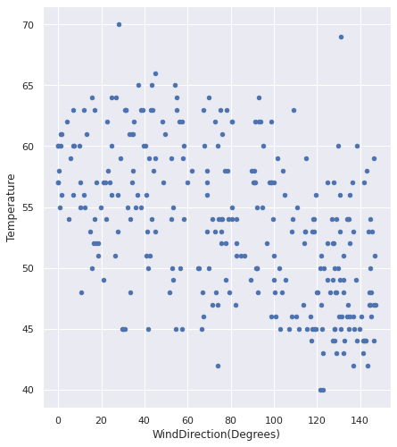

```python
sns.set(rc={'figure.figsize':(7.0,8.27)})
dataset[dataset['WindDirection(Degrees)'] < 147].sample(300).plot.scatter(x='WindDirection(Degrees)', y='Temperature')
```

As we can see, The windDirection and Temperature are weakly correlated

Let's consider the same example but take another baviriot

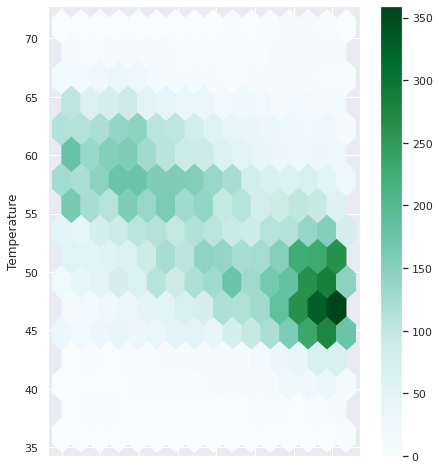

```python
dataset[dataset['WindDirection(Degrees)'] < 147].plot.hexbin(x='WindDirection(Degrees)', y='Temperature', gridsize=15)
```

here, the temperature is strongly correlated with the WindDirection when The temperature is equal to arround 47 and the windDirection 120

# Variable transformations

Here, I want to create new columns to refer to month/year and hours/minutes/seconds and delete the date types

```python
dataset['data_year'] = pd.DatetimeIndex(dataset['Data']).year
dataset['data_month'] = pd.DatetimeIndex(dataset['Data']).month
dataset['time_hour'] = pd.DatetimeIndex(dataset['Time']).hour
dataset['time_minute'] = pd.DatetimeIndex(dataset['Time']).minute
dataset['time_seconds'] = pd.DatetimeIndex(dataset['Time']).second
dataset['timeSunSet_hours'] = pd.DatetimeIndex(dataset['TimeSunSet']).hour
dataset['timeSunSet_minute'] = pd.DatetimeIndex(dataset['TimeSunSet']).minute
dataset['timeSunSet_seconds'] = pd.DatetimeIndex(dataset['TimeSunSet']).second
dataset['timeSunRise_hours'] = pd.DatetimeIndex(dataset['TimeSunRise']).hour
dataset['timeSunRise_minute'] = pd.DatetimeIndex(dataset['TimeSunRise']).minute
dataset['timeSunRise_seconds'] = pd.DatetimeIndex(dataset['TimeSunRise']).second

dataset.drop('Data', inplace=True, axis=1)
dataset.drop('Time', inplace=True, axis=1)
dataset.drop('TimeSunSet', inplace=True, axis=1)
dataset.drop('TimeSunRise', inplace=True, axis=1)
dataset.head()
```

|  | UNIXTime | Radiation | Temperature | Pressure | Humidity | WindDirection(Degrees) | Speed | data_year | data_month | time_hour | time_minute | time_seconds | timeSunSet_hours | timeSunSet_minute | timeSunSet_seconds | timeSunRise_hours | timeSunRise_minute | timeSunRise_seconds |
| --- | --- | --- | --- | --- | --- | --- | --- | --- | --- | --- | --- | --- | --- | --- | --- | --- | --- | --- |
| 0 | 1475229326 | 1.21 | 48 | 30.46 | 59 | 177.39 | 5.62 | 2016 | 9 | 23 | 55 | 26 | 18 | 13 | 0 | 6 | 13 | 0 |
| 1 | 1475229023 | 1.21 | 48 | 30.46 | 58 | 176.78 | 3.37 | 2016 | 9 | 23 | 50 | 23 | 18 | 13 | 0 | 6 | 13 | 0 |
| 2 | 1475228726 | 1.23 | 48 | 30.46 | 57 | 158.75 | 3.37 | 2016 | 9 | 23 | 45 | 26 | 18 | 13 | 0 | 6 | 13 | 0 |
| 3 | 1475228421 | 1.21 | 48 | 30.46 | 60 | 137.71 | 3.37 | 2016 | 9 | 23 | 40 | 21 | 18 | 13 | 0 | 6 | 13 | 0 |
| 4 | 1475228124 | 1.17 | 48 | 30.46 | 62 | 104.95 | 5.62 | 2016 | 9 | 23 | 35 | 24 | 18 | 13 | 0 | 6 | 13 | 0 |

```python
dataset.shape
```

```
(32686, 18)
```

Now, we have 18 columns not only 11, that's it for data transformation

# Missing value treatment

We have already seen that there is no missing value

# Correlation analysis

Here are some correlation analysis using different pandas methods

```python
dataset.corr(method ='pearson')
```

|  | UNIXTime | Radiation | Temperature | Pressure | Humidity | WindDirection(Degrees) | Speed | data_year | data_month | time_hour | time_minute | time_seconds | timeSunSet_hours | timeSunSet_minute | timeSunSet_seconds | timeSunRise_hours | timeSunRise_minute | timeSunRise_seconds |
| --- | --- | --- | --- | --- | --- | --- | --- | --- | --- | --- | --- | --- | --- | --- | --- | --- | --- | --- |
| UNIXTime | 1.000000 | -0.081286 | -0.369169 | -0.332016 | -0.063117 | 0.152613 | 0.173860 | NaN | 0.968235 | 0.001056 | 0.000406 | 0.231002 | -0.818884 | 0.586612 | NaN | NaN | 0.981908 | NaN |
| Radiation | -0.081286 | 1.000000 | 0.734955 | 0.119016 | -0.226171 | -0.230324 | 0.073627 | NaN | -0.095450 | 0.004398 | -0.000730 | -0.031270 | 0.048719 | -0.039816 | NaN | NaN | -0.092850 | NaN |
| Temperature | -0.369169 | 0.734955 | 1.000000 | 0.311173 | -0.285055 | -0.259421 | -0.031458 | NaN | -0.354560 | 0.197464 | -0.001934 | -0.036147 | 0.300920 | -0.242881 | NaN | NaN | -0.380968 | NaN |
| Pressure | -0.332016 | 0.119016 | 0.311173 | 1.000000 | -0.223973 | -0.229010 | -0.083639 | NaN | -0.341759 | 0.091069 | 0.001860 | -0.031102 | 0.151939 | -0.119599 | NaN | NaN | -0.380399 | NaN |
| Humidity | -0.063117 | -0.226171 | -0.285055 | -0.223973 | 1.000000 | -0.001833 | -0.211624 | NaN | -0.068854 | 0.077899 | 0.000499 | -0.027682 | 0.145143 | -0.119526 | NaN | NaN | -0.023955 | NaN |
| WindDirection(Degrees) | 0.152613 | -0.230324 | -0.259421 | -0.229010 | -0.001833 | 1.000000 | 0.073092 | NaN | 0.181485 | -0.077969 | -0.000602 | -0.032568 | -0.078540 | 0.070030 | NaN | NaN | 0.176929 | NaN |
| Speed | 0.173860 | 0.073627 | -0.031458 | -0.083639 | -0.211624 | 0.073092 | 1.000000 | NaN | 0.150822 | -0.057939 | 0.000192 | -0.032934 | -0.159384 | 0.119926 | NaN | NaN | 0.167075 | NaN |
| data_year | NaN | NaN | NaN | NaN | NaN | NaN | NaN | NaN | NaN | NaN | NaN | NaN | NaN | NaN | NaN | NaN | NaN | NaN |
| data_month | 0.968235 | -0.095450 | -0.354560 | -0.341759 | -0.068854 | 0.181485 | 0.150822 | NaN | 1.000000 | -0.005396 | 0.000168 | 0.220563 | -0.784783 | 0.541883 | NaN | NaN | 0.952472 | NaN |
| time_hour | 0.001056 | 0.004398 | 0.197464 | 0.091069 | 0.077899 | -0.077969 | -0.057939 | NaN | -0.005396 | 1.000000 | -0.004052 | 0.004199 | 0.008629 | -0.007056 | NaN | NaN | -0.006772 | NaN |
| time_minute | 0.000406 | -0.000730 | -0.001934 | 0.001860 | 0.000499 | -0.000602 | 0.000192 | NaN | 0.000168 | -0.004052 | 1.000000 | 0.002517 | 0.001052 | -0.002215 | NaN | NaN | -0.000158 | NaN |
| time_seconds | 0.231002 | -0.031270 | -0.036147 | -0.031102 | -0.027682 | -0.032568 | -0.032934 | NaN | 0.220563 | 0.004199 | 0.002517 | 1.000000 | -0.037743 | 0.003571 | NaN | NaN | 0.258917 | NaN |
| timeSunSet_hours | -0.818884 | 0.048719 | 0.300920 | 0.151939 | 0.145143 | -0.078540 | -0.159384 | NaN | -0.784783 | 0.008629 | 0.001052 | -0.037743 | 1.000000 | -0.873471 | NaN | NaN | -0.742329 | NaN |
| timeSunSet_minute | 0.586612 | -0.039816 | -0.242881 | -0.119599 | -0.119526 | 0.070030 | 0.119926 | NaN | 0.541883 | -0.007056 | -0.002215 | 0.003571 | -0.873471 | 1.000000 | NaN | NaN | 0.562851 | NaN |
| timeSunSet_seconds | NaN | NaN | NaN | NaN | NaN | NaN | NaN | NaN | NaN | NaN | NaN | NaN | NaN | NaN | NaN | NaN | NaN | NaN |
| timeSunRise_hours | NaN | NaN | NaN | NaN | NaN | NaN | NaN | NaN | NaN | NaN | NaN | NaN | NaN | NaN | NaN | NaN | NaN | NaN |
| timeSunRise_minute | 0.981908 | -0.092850 | -0.380968 | -0.380399 | -0.023955 | 0.176929 | 0.167075 | NaN | 0.952472 | -0.006772 | -0.000158 | 0.258917 | -0.742329 | 0.562851 | NaN | NaN | 1.000000 | NaN |
| timeSunRise_seconds | NaN | NaN | NaN | NaN | NaN | NaN | NaN | NaN | NaN | NaN | NaN | NaN | NaN | NaN | NaN | NaN | NaN | NaN |

```python
dataset.corr(method ='kendall')
```

|  | UNIXTime | Radiation | Temperature | Pressure | Humidity | WindDirection(Degrees) | Speed | data_year | data_month | time_hour | time_minute | time_seconds | timeSunSet_hours | timeSunSet_minute | timeSunSet_seconds | timeSunRise_hours | timeSunRise_minute | timeSunRise_seconds |
| --- | --- | --- | --- | --- | --- | --- | --- | --- | --- | --- | --- | --- | --- | --- | --- | --- | --- | --- |
| UNIXTime | 1.000000 | -0.107129 | -0.268678 | -0.160785 | -0.033164 | 0.098021 | 0.104670 | NaN | 0.865496 | 0.003163 | 0.001469 | -0.016782 | -0.673600 | 0.267416 | NaN | NaN | 0.988073 | NaN |
| Radiation | -0.107129 | 1.000000 | 0.538313 | 0.031905 | -0.084600 | -0.205663 | -0.015171 | NaN | -0.104878 | 0.016994 | -0.000868 | 0.002823 | 0.122934 | -0.059311 | NaN | NaN | -0.108583 | NaN |
| Temperature | -0.268678 | 0.538313 | 1.000000 | 0.199718 | -0.151589 | -0.269547 | -0.052562 | NaN | -0.285400 | 0.134554 | -0.001460 | 0.024622 | 0.273845 | -0.142150 | NaN | NaN | -0.271955 | NaN |
| Pressure | -0.160785 | 0.031905 | 0.199718 | 1.000000 | -0.150526 | -0.105480 | 0.021822 | NaN | -0.172330 | 0.087580 | 0.001303 | -0.036963 | 0.072041 | -0.039417 | NaN | NaN | -0.163640 | NaN |
| Humidity | -0.033164 | -0.084600 | -0.151589 | -0.150526 | 1.000000 | -0.041277 | -0.156442 | NaN | -0.035150 | 0.065084 | 0.000414 | -0.007909 | 0.077631 | -0.072142 | NaN | NaN | -0.033364 | NaN |
| WindDirection(Degrees) | 0.098021 | -0.205663 | -0.269547 | -0.105480 | -0.041277 | 1.000000 | 0.060362 | NaN | 0.135021 | -0.084714 | -0.001144 | -0.036113 | -0.058164 | 0.036337 | NaN | NaN | 0.100290 | NaN |
| Speed | 0.104670 | -0.015171 | -0.052562 | 0.021822 | -0.156442 | 0.060362 | 1.000000 | NaN | 0.096267 | -0.061030 | -0.000401 | -0.047956 | -0.128737 | 0.074065 | NaN | NaN | 0.105615 | NaN |
| data_year | NaN | NaN | NaN | NaN | NaN | NaN | NaN | 1.0 | NaN | NaN | NaN | NaN | NaN | NaN | NaN | NaN | NaN | NaN |
| data_month | 0.865496 | -0.104878 | -0.285400 | -0.172330 | -0.035150 | 0.135021 | 0.096267 | NaN | 1.000000 | -0.004149 | 0.001346 | -0.004092 | -0.716487 | 0.355904 | NaN | NaN | 0.875416 | NaN |
| time_hour | 0.003163 | 0.016994 | 0.134554 | 0.087580 | 0.065084 | -0.084714 | -0.061030 | NaN | -0.004149 | 1.000000 | -0.003004 | 0.000882 | 0.007206 | -0.003230 | NaN | NaN | -0.005266 | NaN |
| time_minute | 0.001469 | -0.000868 | -0.001460 | 0.001303 | 0.000414 | -0.001144 | -0.000401 | NaN | 0.001346 | -0.003004 | 1.000000 | 0.003142 | 0.000154 | -0.000017 | NaN | NaN | 0.001144 | NaN |
| time_seconds | -0.016782 | 0.002823 | 0.024622 | -0.036963 | -0.007909 | -0.036113 | -0.047956 | NaN | -0.004092 | 0.000882 | 0.003142 | 1.000000 | 0.139772 | -0.030873 | NaN | NaN | -0.018100 | NaN |
| timeSunSet_hours | -0.673600 | 0.122934 | 0.273845 | 0.072041 | 0.077631 | -0.058164 | -0.128737 | NaN | -0.716487 | 0.007206 | 0.000154 | 0.139772 | 1.000000 | -0.686876 | NaN | NaN | -0.681287 | NaN |
| timeSunSet_minute | 0.267416 | -0.059311 | -0.142150 | -0.039417 | -0.072142 | 0.036337 | 0.074065 | NaN | 0.355904 | -0.003230 | -0.000017 | -0.030873 | -0.686876 | 1.000000 | NaN | NaN | 0.280040 | NaN |
| timeSunSet_seconds | NaN | NaN | NaN | NaN | NaN | NaN | NaN | NaN | NaN | NaN | NaN | NaN | NaN | NaN | 1.0 | NaN | NaN | NaN |
| timeSunRise_hours | NaN | NaN | NaN | NaN | NaN | NaN | NaN | NaN | NaN | NaN | NaN | NaN | NaN | NaN | NaN | 1.0 | NaN | NaN |
| timeSunRise_minute | 0.988073 | -0.108583 | -0.271955 | -0.163640 | -0.033364 | 0.100290 | 0.105615 | NaN | 0.875416 | -0.005266 | 0.001144 | -0.018100 | -0.681287 | 0.280040 | NaN | NaN | 1.000000 | NaN |
| timeSunRise_seconds | NaN | NaN | NaN | NaN | NaN | NaN | NaN | NaN | NaN | NaN | NaN | NaN | NaN | NaN | NaN | NaN | NaN | 1.0 |

# Dimensionality Reduction

```python
dataset.dtypes
```

[output not shown]

```python
encoder = LabelEncoder()
for col in dataset.columns:
    dataset[col] = encoder.fit_transform(dataset[col])
feature_cols = ['UNIXTime','Temperature', 'Pressure', 'Humidity', 'WindDirection(Degrees)', 'Speed','data_year','data_month','time_hour','time_minute','time_seconds',
                'timeSunSet_hours','timeSunSet_minute','timeSunSet_seconds','timeSunRise_hours','timeSunRise_minute','timeSunRise_seconds']
X_features = dataset[feature_cols] # Features
y_label = dataset.Radiation # Target variable
scaler = StandardScaler()
X_features = scaler.fit_transform(X_features)
```

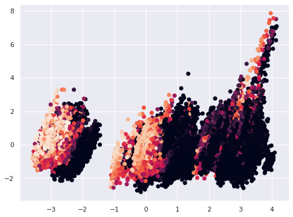

```python
pca2 = PCA(n_components=17)
pca2.fit(X_features)
x_3d = pca2.transform(X_features)

plt.figure(figsize=(8,6))
plt.scatter(x_3d[:,0], x_3d[:,5], c=dataset['Radiation'])
plt.show()
```